# Introduction to Regression Models

Smithsonian’s National Zoo & Conservation Biology Institute

18 September 2024

### Learning Objectives

- Practice loading a real-world dataset into R
- Learn the basics of performing and interpreting a regression analysis
- Understand model assumptions
- Use AIC to compare regression models

## Introduction to Regression in R

Now that you’ve learned the basics of **R** programming and data manipulation, we’ll start working on some basic skills related to data analysis. We will import a dataset from cattle grazing plots in Brazil that includes grazing height, livestock standing stock, grass biomass, grass accumulation rates, and livestock weight gain. The goal of this exercise is to practice some basic skills in **R** programming while reviewing some key ideas in regression modelling. This lesson will help as we move towards our ultimate goal of conducting more advanced analyses on animal count data.

### Preparing to Work in an R Script

As we have done previously, you will want to create an R script:

1. From the “File” menu, select “New File”
2. Click “R Script” from the list of options
3. Save the R script in your working directly in the `Scripts` folder. Name this file `IntroToRegression.R`
4. Make a comment at the top of your script with your name, the date, and the purpose of the script.

```r
# ******************************************************************
# ******************************************************************

# Project: Introduction to Regression in R
# Description: A practice script which an example regression analysis
# Author: <Your Name>
# Date Initialized: <dd month yyyy>

# ******************************************************************
# ******************************************************************
```

### Clear Workspace and Load Packages

As we’ve done previously, we will ‘clean up’ our Workspace when starting a new session. We will also make sure the dplyr and lmtest packages are loaded for doing data manipulation and checking certain model assumptions.

```r
# Clean your workspace/remove all objects
rm(list=ls())

#install.packages("dplyr", "lmtest")
library(dplyr)   # For data manipulation
library(lmtest)  # For checking model assumptions
```

## Data Management

### Exploring the Data

Let’s start investigating a dataset to later fit some regression models.

Load the grazing plot dataset. This dataset should be in the data folder within your R project directory. We will use this simple dataset as it is a good example of a dataset with several possible relationships to explore among response and predictor variables. The data for this exercise were taken from a published manuscript:

- Soares et al., 2020. Ciencia Rural 50(1). DOI: 10.1590/0103-8478cr20180837

```r
# Read dataset
Grazing_Data <- read.csv("Data/GrassHeightData.csv")

# Look at the data
head(Grazing_Data)
```

[output not shown]

Assess the overall structure of the data set to get a sense of the number and type of variables included. When you work with your own data, you will be familiar with the data structure, but it is always good practice to examine your data before moving on to any model fitting. Make sure that the data structure of each column of the data frame is correct and what you expect it to be.

Note, all columns/variables included in this sample dataset are numeric or integer types. You can confirm the data type of each column by typing **is.numeric()** next to the variable name (e.g., `is.numeric(Grazing_Data$GrassHt)`).

```r
str(Grazing_Data)
```

```
## 'data.frame':    12 obs. of  7 variables:
##  $ GrazingHt                 : num  6.6 7.8 8.4 12.8 15.4 18.6 26.8 28 30.8 32.9 ...
##  $ HerbageMass               : num  775 831 944 1488 1845 ...
##  $ LeafLaminaMass            : int  328 478 436 670 742 1060 1096 874 1438 1144 ...
##  $ HerbageAccumulationRate   : num  60.9 78.3 59.1 102 94.8 ...
##  $ LeafLaminaAccumulationRate: num  25.8 44.1 28.4 46.2 36.4 47.6 60.6 60.8 53 46.9 ...
##  $ StockingRate              : num  3914 3700 3818 2841 3742 ...
##  $ WeightGain                : num  -12.1 -7.6 -3.6 1.2 -4.1 -0.6 1.8 3.2 4 2.4 ...
```

Now, summarize the data to provide a list of each variable with the mean, min, and max.

```r
summary(Grazing_Data)
```

```
##    GrazingHt      HerbageMass     LeafLaminaMass HerbageAccumulationRate
##  Min.   : 6.60   Min.   : 774.6   Min.   : 328   Min.   : 59.10
##  1st Qu.:11.70   1st Qu.:1352.2   1st Qu.: 622   1st Qu.: 90.67
##  Median :22.70   Median :2511.8   Median : 967   Median :127.00
##  Mean   :21.96   Mean   :2458.5   Mean   : 975   Mean   :115.84
##  3rd Qu.:31.32   3rd Qu.:3507.1   3rd Qu.:1218   3rd Qu.:143.90
##  Max.   :39.20   Max.   :5000.0   Max.   :1882   Max.   :164.50
##  LeafLaminaAccumulationRate  StockingRate    WeightGain
##  Min.   :25.80              Min.   :2283   Min.   :-12.1000
##  1st Qu.:42.17              1st Qu.:2788   1st Qu.: -3.7250
##  Median :47.25              Median :2938   Median :  1.4000
##  Mean   :47.11              Mean   :3108   Mean   : -0.8333
##  3rd Qu.:56.52              3rd Qu.:3710   3rd Qu.:  2.6000
##  Max.   :60.80              Max.   :3914   Max.   :  4.0000
```

### Basic Plotting

If you plot some data, you should be able to see cases where there seems to be a strong relationship between two variables. “GrazingHt” vs. “HerbageMass” is a good example of this. This is the height that pasture has been grazed to vs. the total biomass of vegetation. We can plot these two variables against each other to examine the relationship closer.

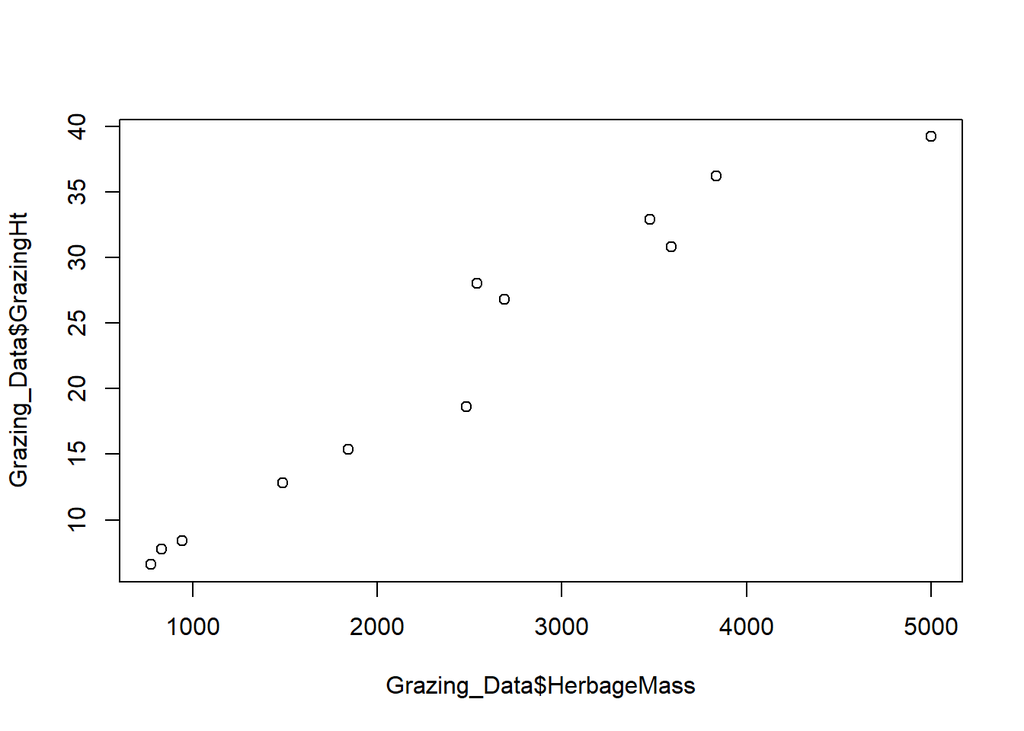

```r
plot(Grazing_Data$HerbageMass, Grazing_Data$GrazingHt)
```

**Question**:

1. Is the slope here positive or negative?

You could plot any of the variables in the dataframe. Plotting the data is one of the simplest ways to look at and explore your data. In **R** you can learn lots of ways to customize your plots. But for now, let’s change the ‘x’ and ‘y’ variable names and add a title to this plot.

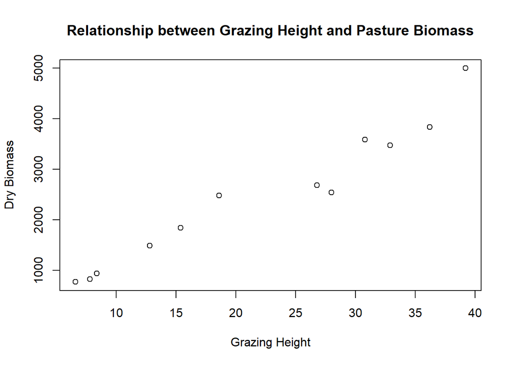

```r
plot(Grazing_Data$HerbageMass ~ Grazing_Data$GrazingHt,
     xlab="Grazing Height",
     ylab="Dry Biomass",
     main="Relationship between Grazing Height and Pasture Biomass")
```

**Questions**:

1. Make a plot to show the relationship between cattle stocking rate and grazing height
2. The `cor(<variable1>,<variable2>)` function can be used to calculate the correlation between two variables. What is the correlation between stocking rate and grazing height? Is this positive or negative?

## Statistical Modelling

Let’s move on to data analysis!

### General principles

When building a statistical model, you need to specify a **dependent variable** (what you are trying to explain) and one or more **independent variables** (the variables that you are using to explain the dependent variable).

Thus, to build a model you will first need to identify the dependent and independent variables based on your research questions. Once you have identified these variables, you need to decide what kind of model structure is appropriate for your dataset. For this reason, knowing models and model structures can help you design the data collection process as you have a good idea of what type of data you need for a specific model.

Running models can be easy, but before you can interpret a model, you need to check that the assumptions of the model are valid **(model validation)**, decide what is the best model structure **(model selection)** and then, finally, **interpret the parameters of the model and/or make predictions.**

The general structure for defining any model in **R** is:

**model.type(dependent.variable ~ independent.variable1 + independent.variable2, data = dataframe)**

Note that in the model equation you do not have to specify the intercept. We have assumed in this example that there are 2 different independent variables in the example provided (independent.variable1 and independent.variable2), but you could build a model that contains any number of independent variables.

### Model design and model fit

Model design involves deciding **what we are trying to explain** (i.e., the dependent variable) and **what we are going to use to explain it** (i.e., the independent variables). These are questions that are informed by the researcher.

Then, we need to decide **what kind of model structure** is appropriate for the dataset. In our case, we will start with a simple linear regression model. Later in the course, however, we will investigate more complex model structures.

Now, we will run several basic linear regression models that attempt to explain how grazing pressure (grazing height) affects various dependent variables, like cattle weight gain and vegetation biomass accumulation rates. Remember to specify the `Grazing_Data` dataset in the model so that **R** understands that the name of dependent and independent variables are columns in that specific dataframe.

```r
# names(Grazing_Data)  # We can print the variable names in our dataset before fitting models
lm1 <- lm(HerbageMass ~ GrazingHt, data = Grazing_Data)
```

### Investigate your model

Once you have fit a model, you can use the summary function to investigate the beta coefficients, SEs, and intercept value.

```r
summary(lm1)
```

```
##
## Call:
## lm(formula = HerbageMass ~ GrazingHt, data = Grazing_Data)
##
## Residuals:
##    Min     1Q Median     3Q    Max
## -590.0 -198.0    7.3  124.1  625.5
##
## Coefficients:
##             Estimate Std. Error t value Pr(>|t|)
## (Intercept)   18.410    211.446   0.087    0.932
## GrazingHt    111.125      8.572  12.964 1.41e-07 ***
## ---
## Signif. codes:  0 '***' 0.001 '**' 0.01 '*' 0.05 '.' 0.1 ' ' 1
##
## Residual standard error: 333.8 on 10 degrees of freedom
## Multiple R-squared:  0.9438, Adjusted R-squared:  0.9382
## F-statistic: 168.1 on 1 and 10 DF,  p-value: 1.408e-07
```

### Model validation

Checking the assumptions of your model

IMPORTANT: Before you can trust your model, you need to examine whether the assumptions on which the model is based are actually valid. **If the assumptions are not satisfied, then your model will be unreliable**, at least to some extent!

If you apply the function **plot** to the model, **R** will provide a series of plots that will help you to inspect model assumptions. Click enter to get all the plots.

```r
plot(lm1)
```

[output not shown]

1. **Assumption 1**: The residuals are normally distributed

Check the Q-Q (quantile-quantile) plot. A perfect normal distribution is represented by a straight line. Your residuals should be close to a straight line. You can also use a Shapiro-Wilk test to see if the **residuals** of your model are significantly different from normal (p<0.05 is bad here!)

```r
shapiro.test(lm1$residuals)
```

[output not shown]

2. **Assumption 2**: The variances of the residuals are homogeneous (homoscedasticity)

The variability of the residuals should be uniform across the range of fitted values of the dependent variable. In the plot of **residuals vs fitted values of y** and **standardized residuals vs. fitted values** there should be a “scatter” of dots across the graphs, with no discernible pattern. Points should be randomly distributed. If you have a scatter of points on one side of the graph, your data may NOT be homogeneous. You can also use a Breush-Pagan test to see if your **residuals** are homogenous (p<0.05 is bad here!)

```r
bptest(lm1)
```

[output not shown]

3. **Assumption 3**: The independent variables are independent of each other (no collinearity)

There are different ways you can address this before you fit your model. For instance, you can estimate the correlation of each pair of covariates and discard variables or exclude them from analysis if they highly correlated (positively or negatively). For example, we would not want a model with stocking rate and grazing height as independent variables, because they are highly correlated with each other.

4. **Assumption 4**: The data set does not contain serial auto-correlation

Serial autocorrelation is when there is significant correlation between successive data points in the data set. Spatial data or time-series data tend to be autocorrelated. There are different ways to deal with autocorrelation, such as using mixed-effect models.

5. **Assumption 5**: The model is not biased by unduly influential observations.

We can check this by looking at the plot of standardized residuals vs leverage and “Cook’s Distance.”

Leverage is a measure of the influence of individual data points on the model’s parameters, measured on the scale of 0-1, where high values indicate a strong influence on the model’s parameters.

Cook’s distance is the sum of squared distances between the fitted values using the whole data set, and the fitted values with the *i*th observation removed. A large difference indicates that the *i*th observation exerts a strong influence on the model’s parameters.

We don’t want values beyond 1. Our 12th observation has a Cook’s distance close to 1, but we aren’t too concerned about outlier effects.

### Visualizing model output

The intercept of 18.4096964 sets the start of the regression line at the grazing height of zero. In this case, this isn’t very useful (grazing height should never reach 0!) but it is a necessary element of describing a linear relationship. Here, the equation for the line is `HerbageMass = 18.41 + 111.13*GrazingHt`. Note that you can call the individual coefficients from a model directly using, in this example, “lm1$coefficients”.

Now, plot again a scatterplot of HerbageMass vs. GrazingHt and draw the regression line.

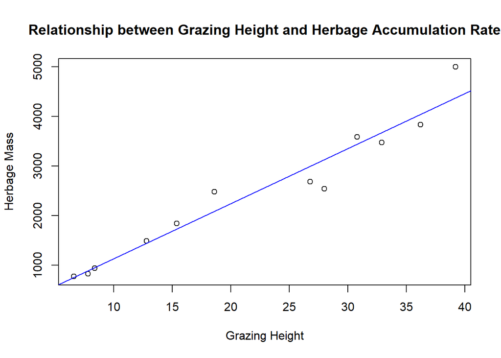

```r
plot(HerbageMass ~ GrazingHt, data = Grazing_Data,
     xlab="Grazing Height",
     ylab="Herbage Mass",
     main="Relationship between Grazing Height and Herbage Accumulation Rate")
abline(lm1, col="blue")
```

## Model Selection

In any mathematical modeling approach, there may be other variables, or some combination of variables, that are best at predicting your response variable of interest. In this case, let’s explore using `HerbageAccumulationRate` as a response variable. Are there any variables that you expect might predict `HerbageAccumulationRate`? Grazing height (`GrazingHt`) seems potentially informative, as shorter grass is expected to grow slower than taller grass. The question now is whether there is a **better** model for predicting `HerbageAccumulationRate`. If we plot the relationship between these two variables, we see that herbage accumulation rate seems to level off above 25cm grazing height. One option is to consider adding a **quadratic** term to the model to better fit a ‘non-linear’ relationship.

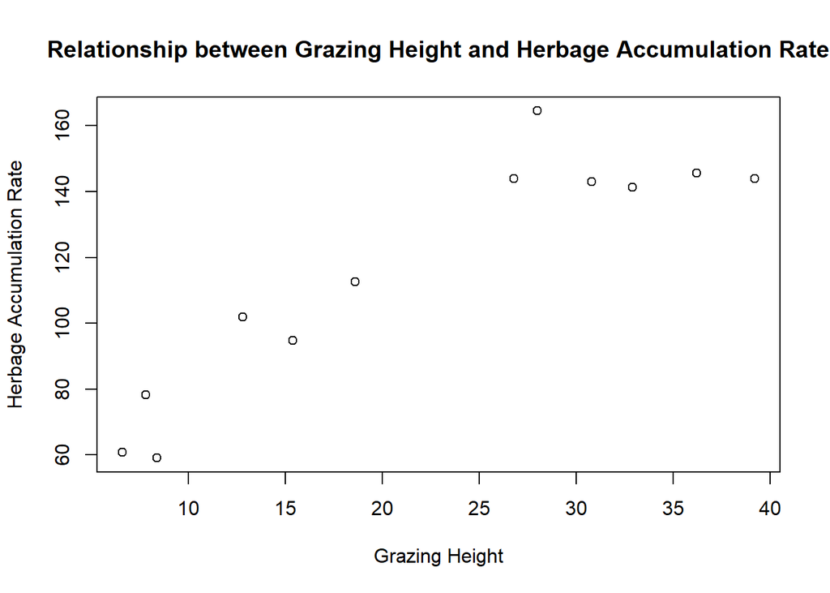

```r
plot(Grazing_Data$HerbageAccumulationRate ~ Grazing_Data$GrazingHt,
     xlab="Grazing Height",
     ylab="Herbage Accumulation Rate",
     main="Relationship between Grazing Height and Herbage Accumulation Rate")
```

Let’s say we have two options:  
1. $HerbageAccumulationRate$ ~ $GrazingHt$  
2. $HerbageAccumulationRate$ ~ $GrazingHt$ + $GrazingHt^2$

We’ve already fitted a first model. Let’s fit linear regression models for the next two parameter combinations we’re interested in. We will give them unique names (`lm2` and `lm3`), and look at the summary of their results.

```r
lm2 <- lm(HerbageAccumulationRate ~ GrazingHt, data = Grazing_Data)
summary(lm2)
```

```
##
## Call:
## lm(formula = HerbageAccumulationRate ~ GrazingHt, data = Grazing_Data)
##
## Residuals:
##      Min       1Q   Median       3Q      Max
## -20.5815 -10.6424  -0.1624   7.7479  31.6144
##
## Coefficients:
##             Estimate Std. Error t value Pr(>|t|)
## (Intercept)  53.8958     9.9040   5.442 0.000284 ***
## GrazingHt     2.8211     0.4015   7.027  3.6e-05 ***
## ---
## Signif. codes:  0 '***' 0.001 '**' 0.01 '*' 0.05 '.' 0.1 ' ' 1
##
## Residual standard error: 15.63 on 10 degrees of freedom
## Multiple R-squared:  0.8316, Adjusted R-squared:  0.8147
## F-statistic: 49.37 on 1 and 10 DF,  p-value: 3.599e-05
```

```r
lm3 <- lm(HerbageAccumulationRate ~ GrazingHt + I(GrazingHt^2), data = Grazing_Data)
summary(lm3)
```

```
##
## Call:
## lm(formula = HerbageAccumulationRate ~ GrazingHt + I(GrazingHt^2),
##     data = Grazing_Data)
##
## Residuals:
##      Min       1Q   Median       3Q      Max
## -12.4036  -6.7120  -0.9579   3.2265  20.6603
##
## Coefficients:
##                Estimate Std. Error t value Pr(>|t|)
## (Intercept)    10.56687   13.90599   0.760 0.466764
## GrazingHt       8.12724    1.51517   5.364 0.000454 ***
## I(GrazingHt^2) -0.12027    0.03378  -3.560 0.006118 **
## ---
## Signif. codes:  0 '***' 0.001 '**' 0.01 '*' 0.05 '.' 0.1 ' ' 1
##
## Residual standard error: 10.62 on 9 degrees of freedom
## Multiple R-squared:  0.9301, Adjusted R-squared:  0.9145
## F-statistic: 59.84 on 2 and 9 DF,  p-value: 6.327e-06
```

As you can see, both of these models seem very strong. Which of the two is best? Akaike’s Information Criteria (AIC) provides a useful tool for comparing models. AIC ranks a model’s performance by accounting for model fit while penalizing models with more variables. You might know that when you add more independent variables to a model, the model fit will often improve. But, it is certainly not ideal to have a model with a large number of independent variables (because we want to avoid overfitting). When adding a variable, the improved fit of the model must outweigh the AIC penalty, otherwise the improved fit will not be deemed worthwhile given the additional model complexity.

Use the `AIC` function to compare the AIC values of our next models. The lowest AIC indicates that the model is a “better” representation of the data and has a better predictive power. Note, AIC is not a measure of model fit.

```r
AIC(lm2)
```

```
## [1] 103.8529
```

```r
AIC(lm3)
```

```
## [1] 95.30584
```

The best model (from the two we have tried) for predicting herbage accumulation rate assumes a non-linear (quadratic) relationship is best (`lm3`).

Let’s make a plot showing the predicted relationship between grazing height and herbage accumulation rate. To show confidence intervals, we will use our model to predict accumulation rate across a range of grazing height values from 0 to 40.

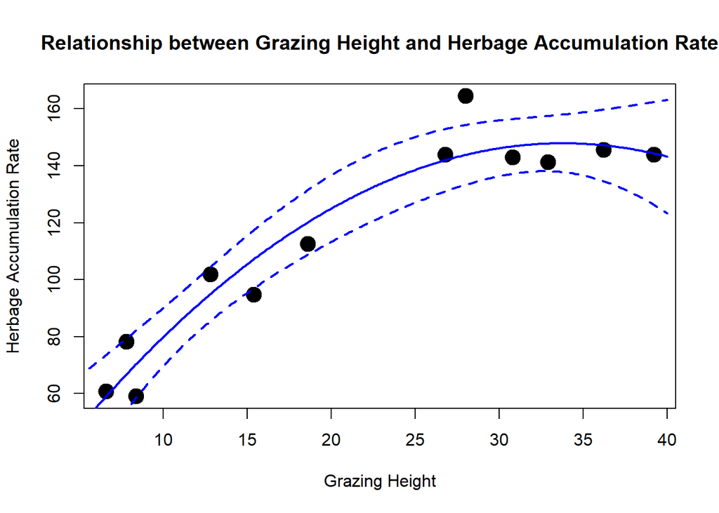

```r
# Create a new sequence of grazing height values
new_GrazingHt = seq(0, 40, by=0.1)

# Use the 'predict' function to predict the herbage accumulation rate across the range of grass height
conf_interval <- predict(lm3, newdata=data.frame(GrazingHt=new_GrazingHt), interval="confidence", level = 0.95)

# Make a scatterplot of the observed data points
plot(Grazing_Data$GrazingHt, Grazing_Data$HerbageAccumulationRate,
     xlab="Grazing Height",
     ylab="Herbage Accumulation Rate",
     main="Relationship between Grazing Height and Herbage Accumulation Rate",
     cex=2, pch=19)

# Add lines that plot the mean, upper confidence interval, and lower confidence interval
lines(new_GrazingHt, conf_interval[,1], col="blue", lwd=2)
lines(new_GrazingHt, conf_interval[,2], col="blue", lty=2, lwd=2)
lines(new_GrazingHt, conf_interval[,3], col="blue", lty=2,lwd=2)
```

With a little extra work (not shown here), we can also use predictions from our model to calculate the estimated annual herbage production in pastures grazed at various heights. As a single point for comparison, we can see that a pasture grazed to 2cm height would be expected to have only about 20% of the annual production of a pasture grazed to 30-40cm!

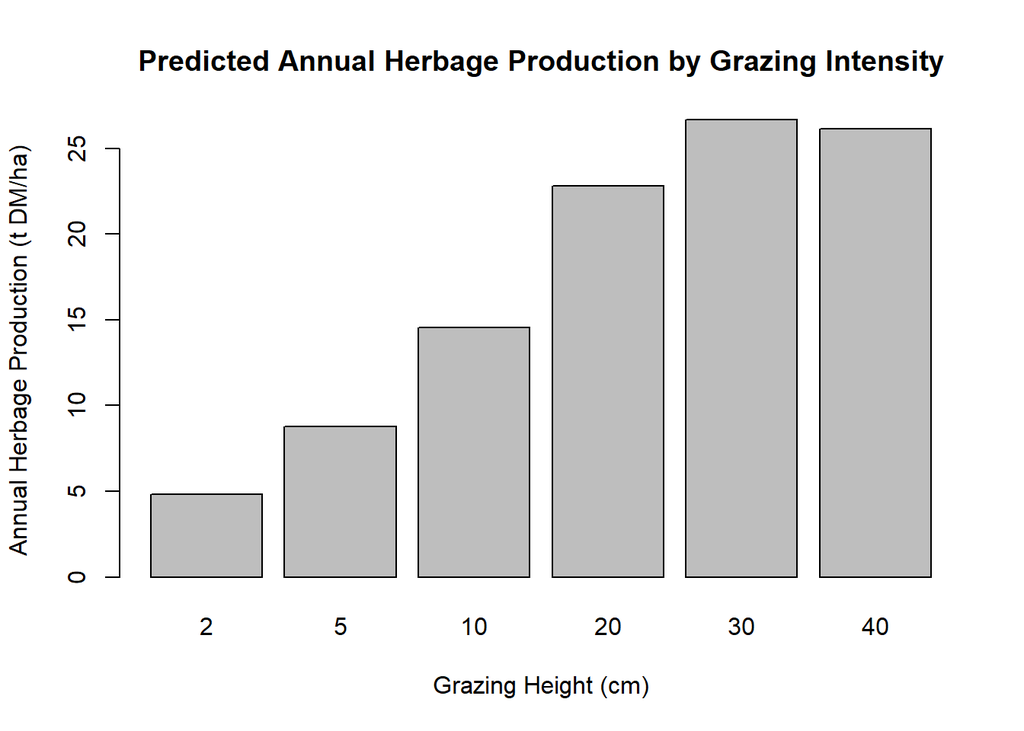

## Exercise

Now that you’ve seen a few examples of linear regression models in R, let’s practice what you’ve learned by making new models for cattle weight gain!

Please create a script named `Exercise_Regression.R`. Format the script like we have instructed you to do with your `Name`, `Date`, and `Description`. Fully comment your code to answer the questions below.

1. What is the effect of herbage mass on cattle weight gain?
2. What is the equation for the best-fit line (look at your coefficients)?
3. Is a quadratic (non-linear) model with Herbage Mass better than a simple linear model?
4. Can you find a better model for cattle weight gain?
5. Does this model meet Assumptions 1, 2, and 5?
6. Explore this dataset and fit some other models that seem interesting to you.

Challenge Question:

6. Fit a model with weight gain predicted by stocking rate. At **exactly** what Stocking Rate threshold does the model predict that cattle can no longer gain weight (i.e., where predicted weight gain is == 0). Hint: you will need to do some math with the regression equation to figure out where along the x-axis cattle weight gain switches to negative values.